# R Notebook

```r
library(nycflights13)
library(tidyverse)
```

`mutate()` always adds new columns at the end of your dataset.

```r
flights_sml <- select(flights,
  year:day,
  ends_with("delay"),
  distance,
  air_time
)

mutate(flights_sml,
  gain = dep_delay - arr_delay,
  speed = distance / air_time * 60
)
```

If you only want to keep the new variables, use `transmute()`.

| gain | hours | gain_per_hour |
| --- | --- | --- |
| -9 | 3.7833333 | -2.3788546 |
| -16 | 3.7833333 | -4.2290749 |
| -31 | 2.6666667 | -11.6250000 |
| 17 | 3.0500000 | 5.5737705 |
| 19 | 1.9333333 | 9.8275862 |
| -16 | 2.5000000 | -6.4000000 |
| -24 | 2.6333333 | -9.1139241 |
| 11 | 0.8833333 | 12.4528302 |
| 5 | 2.3333333 | 2.1428571 |
| -10 | 2.3000000 | -4.3478261 |

[output cut: 990 more lines]

**Useful creation functions**

- Arithmetic operators: +, -, *, /, ^
- Modular arithmetic: `%/%` (integer division) and `%%` (remainder), where x == y * (x %/% y) + (x %% y)
- Logs: log(), log2(), log10()
- Offsets: lead() and lag() allow you to refer to leading or lagging values.

```r
x <- 1:10
lag(x)
```

```
 [1] NA  1  2  3  4  5  6  7  8  9
```

```r
lead(x)
```

```
 [1]  2  3  4  5  6  7  8  9 10 NA
```

- Cumulative and rolling aggregates: R provides functions for running sums, products, mins and maxes: `cumsum()`, `cumprod()`, `cummin()`, `cummax()`; and dplyr provides `cummean()` for cumulative means.

```r
cumsum(x)
```

```
 [1]  1  3  6 10 15 21 28 36 45 55
```

```r
cummean(x)
```

```
 [1] 1.0 1.5 2.0 2.5 3.0 3.5 4.0 4.5 5.0 5.5
```

- Logical comparisons, <, <=, >, >=, !=, and ==;
- Ranking: there are a number of ranking functions, but you should start with `min_rank()`.

**Exercise**

1. Currently `dep_time` and `sched_dep_time` are convenient to look at, but hard to compute with because they’re not really continuous numbers. Convert them to a more convenient representation of number of minutes since midnight.

| dep_time | dep_time_mins | sched_dep_time | sched_dep_time_mins |
| --- | --- | --- | --- |
| 517 | 317 | 515 | 315 |
| 533 | 333 | 529 | 329 |
| 542 | 342 | 540 | 340 |
| 544 | 344 | 545 | 345 |
| 554 | 354 | 600 | 360 |
| 554 | 354 | 558 | 358 |
| 555 | 355 | 600 | 360 |
| 557 | 357 | 600 | 360 |
| 557 | 357 | 600 | 360 |
| 558 | 358 | 600 | 360 |

[output cut: 990 more lines]

2. Compare `air_time` with `arr_time` - `dep_time`. What do you expect to see? What do you see? What do you need to do to fix it?

```r
flights_airtime <- mutate(flights, dep_time = time2mins(dep_time), arr_time = time2mins(arr_time),
                         air_time_diff = air_time - arr_time + dep_time)

nrow(filter(flights_airtime, air_time_diff != 0))
```

```
[1] 327150
```

3. Compare `dep_time`, `sched_dep_time`, and `dep_delay`. How would you expect those three numbers to be related?

```r
flights_deptime <-
  mutate(flights,
    dep_time_min = (dep_time %/% 100 * 60 + dep_time %% 100) %% 1440,
    sched_dep_time_min = (sched_dep_time %/% 100 * 60 +
      sched_dep_time %% 100) %% 1440,
    dep_delay_diff = dep_delay - dep_time_min + sched_dep_time_min
  )

nrow(filter(flights_deptime, dep_delay_diff != 0))
```

```
[1] 1236
```

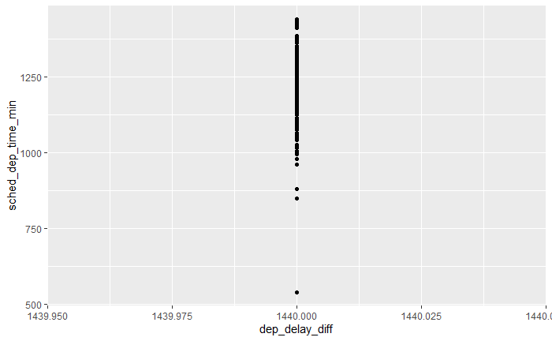

4. Find the 10 most delayed flights using a ranking function. How do you want to handle ties?

| x | x_row_number | x_min_rank | x_dense_rank |
| --- | --- | --- | --- |
| 1 | 1 | 1 | 1 |
| 5 | 2 | 2 | 2 |
| 5 | 3 | 2 | 2 |
| 5 | 4 | 2 | 2 |
| 10 | 5 | 5 | 3 |

The `min_rank()` function assigns a rank equal to the number of values less than that tied value plus one. In contrast, the `dense_rank()` function assigns a rank equal to the number of distinct values less than that tied value plus one.

| year | month | day | dep_time | sched_dep_time | dep_delay | arr_time | sched_arr_time | arr_delay | carrier | flight | tailnum | origin | dest | air_time | distance | hour | minute | time_hour | dep_delay_min_rank | dep_delay_row_number | dep_delay_dense_rank |
| --- | --- | --- | --- | --- | --- | --- | --- | --- | --- | --- | --- | --- | --- | --- | --- | --- | --- | --- | --- | --- | --- |
| 2013 | 1 | 9 | 641 | 900 | 1301 | 1242 | 1530 | 1272 | HA | 51 | N384HA | JFK | HNL | 640 | 4983 | 9 | 0 | 2013-01-09 09:00:00 | 1 | 1 | 1 |
| 2013 | 6 | 15 | 1432 | 1935 | 1137 | 1607 | 2120 | 1127 | MQ | 3535 | N504MQ | JFK | CMH | 74 | 483 | 19 | 35 | 2013-06-15 19:00:00 | 2 | 2 | 2 |
| 2013 | 1 | 10 | 1121 | 1635 | 1126 | 1239 | 1810 | 1109 | MQ | 3695 | N517MQ | EWR | ORD | 111 | 719 | 16 | 35 | 2013-01-10 16:00:00 | 3 | 3 | 3 |
| 2013 | 9 | 20 | 1139 | 1845 | 1014 | 1457 | 2210 | 1007 | AA | 177 | N338AA | JFK | SFO | 354 | 2586 | 18 | 45 | 2013-09-20 18:00:00 | 4 | 4 | 4 |
| 2013 | 7 | 22 | 845 | 1600 | 1005 | 1044 | 1815 | 989 | MQ | 3075 | N665MQ | JFK | CVG | 96 | 589 | 16 | 0 | 2013-07-22 16:00:00 | 5 | 5 | 5 |
| 2013 | 4 | 10 | 1100 | 1900 | 960 | 1342 | 2211 | 931 | DL | 2391 | N959DL | JFK | TPA | 139 | 1005 | 19 | 0 | 2013-04-10 19:00:00 | 6 | 6 | 6 |
| 2013 | 3 | 17 | 2321 | 810 | 911 | 135 | 1020 | 915 | DL | 2119 | N927DA | LGA | MSP | 167 | 1020 | 8 | 10 | 2013-03-17 08:00:00 | 7 | 7 | 7 |
| 2013 | 6 | 27 | 959 | 1900 | 899 | 1236 | 2226 | 850 | DL | 2007 | N3762Y | JFK | PDX | 313 | 2454 | 19 | 0 | 2013-06-27 19:00:00 | 8 | 8 | 8 |
| 2013 | 7 | 22 | 2257 | 759 | 898 | 121 | 1026 | 895 | DL | 2047 | N6716C | LGA | ATL | 109 | 762 | 7 | 59 | 2013-07-22 07:00:00 | 9 | 9 | 9 |
| 2013 | 12 | 5 | 756 | 1700 | 896 | 1058 | 2020 | 878 | AA | 172 | N5DMAA | EWR | MIA | 149 | 1085 | 17 | 0 | 2013-12-05 17:00:00 | 10 | 10 | 10 |

There are other ways to solve this problem that do not using ranking functions. To select the top 10, sort values with `arrange()` and select the top values with `slice`:

```r
flights_delay_2 <- arrange(flights, desc(dep_delay))
flights_delay_2 <- slice(flights_delay_2, 1:10)
select(flights_delay_2,  month, day, carrier, flight, dep_delay)
```

| month | day | carrier | flight | dep_delay |
| --- | --- | --- | --- | --- |
| 1 | 9 | HA | 51 | 1301 |
| 6 | 15 | MQ | 3535 | 1137 |
| 1 | 10 | MQ | 3695 | 1126 |
| 9 | 20 | AA | 177 | 1014 |
| 7 | 22 | MQ | 3075 | 1005 |
| 4 | 10 | DL | 2391 | 960 |
| 3 | 17 | DL | 2119 | 911 |
| 6 | 27 | DL | 2007 | 899 |
| 7 | 22 | DL | 2047 | 898 |
| 12 | 5 | AA | 172 | 896 |

Alternatively, we could use the `top_n()`.

```r
flights_delayed3 <- top_n(flights, 10, dep_delay)
flights_delayed3 <- arrange(flights_delayed3, desc(dep_delay))
select(flights_delayed3, month, day, carrier, flight, dep_delay)
```

| month | day | carrier | flight | dep_delay |
| --- | --- | --- | --- | --- |
| 1 | 9 | HA | 51 | 1301 |
| 6 | 15 | MQ | 3535 | 1137 |
| 1 | 10 | MQ | 3695 | 1126 |
| 9 | 20 | AA | 177 | 1014 |
| 7 | 22 | MQ | 3075 | 1005 |
| 4 | 10 | DL | 2391 | 960 |
| 3 | 17 | DL | 2119 | 911 |
| 6 | 27 | DL | 2007 | 899 |
| 7 | 22 | DL | 2047 | 898 |
| 12 | 5 | AA | 172 | 896 |

5. What does 1:3 + 1:10 return? Why?

```r
1:3 + 1:10
```

```
 [1]  2  4  6  5  7  9  8 10 12 11
```

This is equivalent to the following.

```r
c(1 + 1, 2 + 2, 3 + 3, 1 + 4, 2 + 5, 3 + 6, 1 + 7, 2 + 8, 3 + 9, 1 + 10)
```

```
 [1]  2  4  6  5  7  9  8 10 12 11
```